# Practical Machine Learning Project

David Goodman

2015-03-22

## Setup

### Loading the Data into R

The data provided was stored in a .csv file. The following code was used to load the raw data into a data frame called `Pml_raw`.

```r
# Load library for reading .csv file
library(gdata)

# Set working directory
setwd("/Users/dagoodma/machinelearning/project/src")
# Load the data and put it into a data frame
mydata <- read.csv("../data/pml-training.csv")
Pml_raw <- data.frame(mydata)
```

### Exploratory Analysis

The first step was to perform exploratory analysis to look for relationships between variables. I found it difficult to look through all of the data because there were nearly 160 different variables. Values for some of the variables were `N/A` in most rows. Except for where the *new_window* column was “yes”. This is described in more detail later.

I noticed a strong relationship between outcome (class) and the Euler angles (yaw, pitch, and roll) derived from the belt accelerometer. These variables are plotted below against index. Notice how the points are spread along the y-axis differently for each class. There appears to be a lot more variance in some values over others. This can be seen in the figures below.

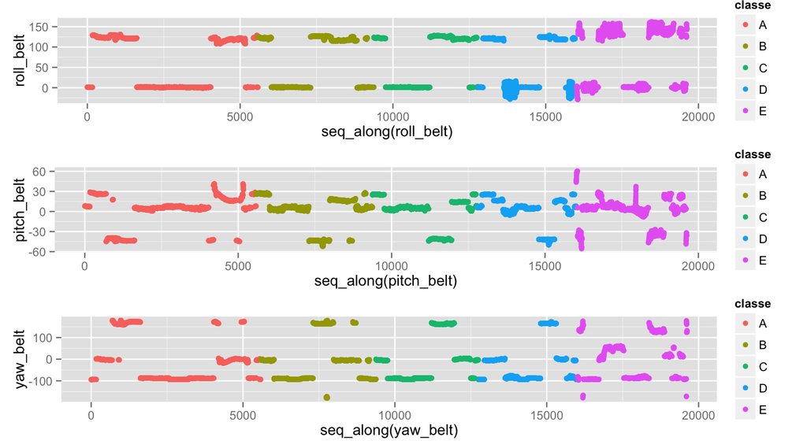

```r
library(ggplot2)
library(gridExtra)
br <- qplot(y=roll_belt,data=Pml_raw,colour=classe)
bp <- qplot(y=pitch_belt,data=Pml_raw,colour=classe)
by <- qplot(y=yaw_belt,data=Pml_raw,colour=classe)
grid.arrange(br,bp,by,nrow=3)
```

Additionally, I noticed a very weak relationship between the dumbbell sensor data and the outcome. Below is a plot of dumbbell Euler angles vs index. Notice how all of the classes look similarly spread along the y-axis. This led me to believe that the dumbbell sensor contained less useful information.

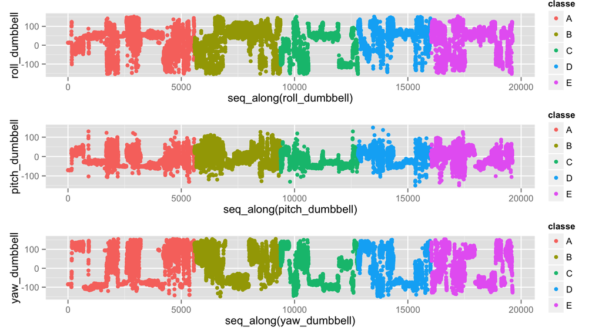

```r
library(ggplot2)
library(gridExtra)
dr <- qplot(y=roll_dumbbell,data=Pml_raw,colour=classe)
dp <- qplot(y=pitch_dumbbell,data=Pml_raw,colour=classe)
dy <- qplot(y=yaw_dumbbell,data=Pml_raw,colour=classe)
grid.arrange(dr,dp,dy,nrow=3)
```

## Methods

### Cleaning the Data

The most important task in this project was to understand the data provided, and to prune and consolidate it. In order to compress the variables, I decided to use only the average Euler angle values recorded at each new window to build my predictor. This allowed me to create a much simpler model that took less time to compile. The code below shows how the data was pruned to grab only the desired columns and rows.

```r
# Load library for rename()
library(plyr)

# Use only new windows, to use average values across window
inWinRow <- which(Pml_raw[,"new_window"] == "yes")

# Find only the columns to use in model
keepPatterns <- c("X", "^avg", "^total", "classe") # col name patterns
inKeepCol <- unique(grep(paste(keepPatterns,collapse="|"), names(Pml_raw)), value=TRUE)

# Keep only the windowed data and desired columns
Pml <- Pml_raw[inWinRow,inKeepCol]

# Rename columns called avg_* so that we can predict on test data,
# which is not in a window
Pml <- rename(Pml, c("avg_roll_belt"="roll_belt", "avg_pitch_belt"="pitch_belt", "avg_yaw_belt"="yaw_belt",
    "avg_roll_arm"="roll_arm", "avg_pitch_arm"="pitch_arm", "avg_yaw_arm"="yaw_arm",
    "avg_roll_forearm"="roll_forearm", "avg_pitch_forearm"="pitch_forearm", "avg_yaw_forearm"="yaw_forearm",
    "avg_roll_dumbbell"="roll_dumbbell", "avg_pitch_dumbbell"="pitch_dumbbell", "avg_yaw_dumbbell"="yaw_dumbbell"))

# Print out pruned data frame names
names(Pml)
```

```
##  [1] "X"                    "total_accel_belt"     "roll_belt"
##  [4] "pitch_belt"           "yaw_belt"             "total_accel_arm"
##  [7] "roll_arm"             "pitch_arm"            "yaw_arm"
## [10] "total_accel_dumbbell" "roll_dumbbell"        "pitch_dumbbell"
## [13] "yaw_dumbbell"         "total_accel_forearm"  "roll_forearm"
## [16] "pitch_forearm"        "yaw_forearm"          "classe"
```

### Building the Predictor

Many attempts were made at producing an accurate predictor. I decided to use *random forests* to build my predictor, because it is supposedly a very accurate model for classification using regression. I also tried many other models. All of the code from previous attempts can be found in the *src/* folder. The code for my final prediction algorithm can be seen below. I performed cross-validation by splitting the training data training (75%) and testing (25%) data. Caret’s train function also performs bagging internally when training the random tree model.

```r
# Load libraries
library(caret)

# Partition data for cross-validation
inTrain <- createDataPartition(y=Pml$classe, p=0.75, list=FALSE)
training <- Pml[inTrain,]
testing <- Pml[-inTrain,]

# Build random forest model from training data
modFit <- train(classe ~ ., method="rf", data=training, prox=TRUE)
print(modFit)
```

```
## Random Forest
##
## 307 samples
##  17 predictor
##   5 classes: 'A', 'B', 'C', 'D', 'E'
##
## No pre-processing
## Resampling: Bootstrapped (25 reps)
##
## Summary of sample sizes: 307, 307, 307, 307, 307, 307, ...
##
## Resampling results across tuning parameters:
##
##   mtry  Accuracy   Kappa      Accuracy SD  Kappa SD
##    2    0.9178008  0.8960281  0.031150589  0.03935501
##    9    0.9907959  0.9883550  0.008304490  0.01050740
##   17    0.9886437  0.9856116  0.009862557  0.01256921
##
## Accuracy was used to select the optimal model using  the largest value.
## The final value used for the model was mtry = 9.
```

```r
# Run on "sub-training" testing data
test1Pred <- predict(modFit, newdata=testing)
confusionMatrix(testing$classe, test1Pred)
```

```
## Confusion Matrix and Statistics
##
##           Reference
## Prediction  A  B  C  D  E
##          A 27  0  0  0  0
##          B  0 19  0  0  0
##          C  0  0 17  0  0
##          D  0  0  0 17  0
##          E  0  0  0  0 19
##
## Overall Statistics
##
##                Accuracy : 1
##                  95% CI : (0.9634, 1)
##     No Information Rate : 0.2727
##     P-Value [Acc > NIR] : < 2.2e-16
##
##                   Kappa : 1
##  Mcnemar's Test P-Value : NA
##
## Statistics by Class:
##
##                      Class: A Class: B Class: C Class: D Class: E
## Sensitivity            1.0000   1.0000   1.0000   1.0000   1.0000
## Specificity            1.0000   1.0000   1.0000   1.0000   1.0000
## Pos Pred Value         1.0000   1.0000   1.0000   1.0000   1.0000
## Neg Pred Value         1.0000   1.0000   1.0000   1.0000   1.0000
## Prevalence             0.2727   0.1919   0.1717   0.1717   0.1919
## Detection Rate         0.2727   0.1919   0.1717   0.1717   0.1919
## Detection Prevalence   0.2727   0.1919   0.1717   0.1717   0.1919
## Balanced Accuracy      1.0000   1.0000   1.0000   1.0000   1.0000
```

```r
# Run on testing data to predict answers
setwd("/Users/dagoodma/machinelearning/project/src")
testdata <- read.csv("../data/pml-testing.csv")
Pml_test <- data.frame(testdata)
test2Pred <- predict(modFit, newdata=Pml_test)
test2Pred
```

```
##  [1] A A A A A A A A A A A A A A A A A A A A
## Levels: A B C D E
```

## Conclusion

This project was very interesting. It showed me that you really do need to use a good amount of science to pick apart the data and find decent features to build a predictor with. Achieving good out of sample accuracy seems to be more difficult than I thought.

I did learn a lot about big data and how to work with it inside of R. Also, learning rmarkdown was helpful. I was quite impressed with it actually. Previously, I have only used Latex to type up reports and documents.